# Data Normalization and QC (Mouse)

Jan Sauer

12.10.2017

This vignette visualizes data normalization and QC.

# 1 Data preprocessing

The data preprocessing consists of the following steps:

- Separate objects into “organoids” (area >= 2500 pixels) and “shrapnel” (area <= 2500 pixels).
- Calculate the summary features for each of these categories of objects within a well (median / mad).
- I decided for this summary statistic as some features may only have features within a certain range, e.g. [0, 1] for the asphericity. Even under the assumption of normally distributed variation within a well, this limitation would cause the mean to skew the summary statistic towards the middle of the interval.
- Apply glog transformation
- Subtract the median of the DMSO wells from each feature on each plate to eliminate batch effects.
- Combine plates belonging to a single cell line and calculate the z-score for each feature.

This is done in an external python script. The data and all intermediate steps are stored in the corresponding hdf5 files in the PROMISE features directory.

```r
cell_lines = unique(substr(list.files(featuresdir, pattern = "M001"), 1, 7))
features = setNames(
  object = vector(mode="list", length=length(cell_lines)),
  nm = cell_lines)
features_metadata = setNames(
  object = vector(mode="list", length=length(cell_lines)),
  nm = cell_lines)
for(cell_line in cell_lines) {
  cl_feature_fn = file.path(feature_dir, sprintf("%s_averaged_features_%s.h5", cell_line, feature_type))
  features[[cell_line]] = data.frame(h5read(cl_feature_fn, hdf5_dataset))
  colnames(features[[cell_line]]) = h5read(cl_feature_fn, "feature_names")
  rownames(features[[cell_line]]) = h5read(cl_feature_fn, "well_names")

  features_metadata[[cell_line]] = data.frame(
    "REPLICATE" = h5read(cl_feature_fn, "replicates"),
    "DRUG" = h5read(cl_feature_fn, "drugs"),
    row.names = rownames(features[[cell_line]]))
  H5close()
}
features = do.call(rbind, features)
rownames(features) = sapply(strsplit(rownames(features), ".", fixed = TRUE), "[[", 2)
features_metadata = do.call(rbind, features_metadata)
rownames(features_metadata) = sapply(strsplit(rownames(features_metadata), ".", fixed = TRUE), "[[", 2)
```

# 2 Quality Control

## 2.1 Comparing Positive controls

The drugs Bortezomib (PS-341) is a potential positive control. To see how suitable it is for this, I look at how they compare to DMSO, the negative control. To compare treatments, I look at the number of organoids as a proxy for organoid survival.

```r
sf_drug = features_metadata[,"DRUG"]
sf_num_organoids = features[,"organoids_num.of.objects"]
sf_avg_org_size = features[,"organoids_x.0.s.area_expected"]
sf_total_area = features[,"Total.Biomass"]

simple_features = data.frame(
  "Num.Objects" = sf_num_organoids,
  "Avg.Org.Size" = sf_avg_org_size,
  "Total.Area" = sf_total_area,
  "Drug" = sf_drug,
  "Cell.Line" = substr(rownames(features), 1, 7)
)
```

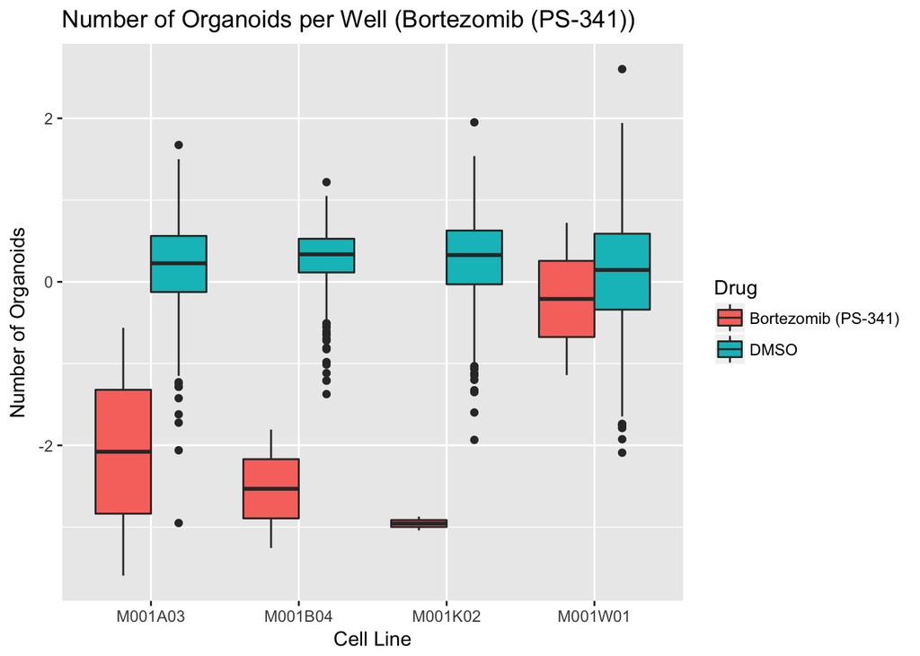

```r
ggplotdf = simple_features[simple_features$Drug %in% c("DMSO", "Bortezomib (PS-341)"),]
ggplot(data = ggplotdf) + geom_boxplot(aes(x = Cell.Line, y = Num.Objects, fill = Drug)) +
  ggtitle(label = "Number of Organoids per Well (Bortezomib (PS-341))") + xlab("Cell Line") +
  ylab("Number of Organoids")
```

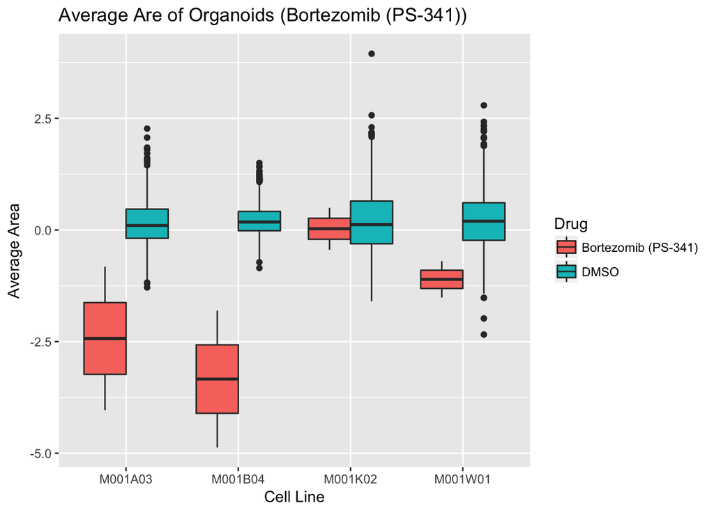

```r
ggplot(data = ggplotdf) + geom_boxplot(aes(x = Cell.Line, y = Avg.Org.Size, fill = Drug)) +
  ggtitle(label = "Average Are of Organoids (Bortezomib (PS-341))") +
  xlab("Cell Line") + ylab("Average Area")
```

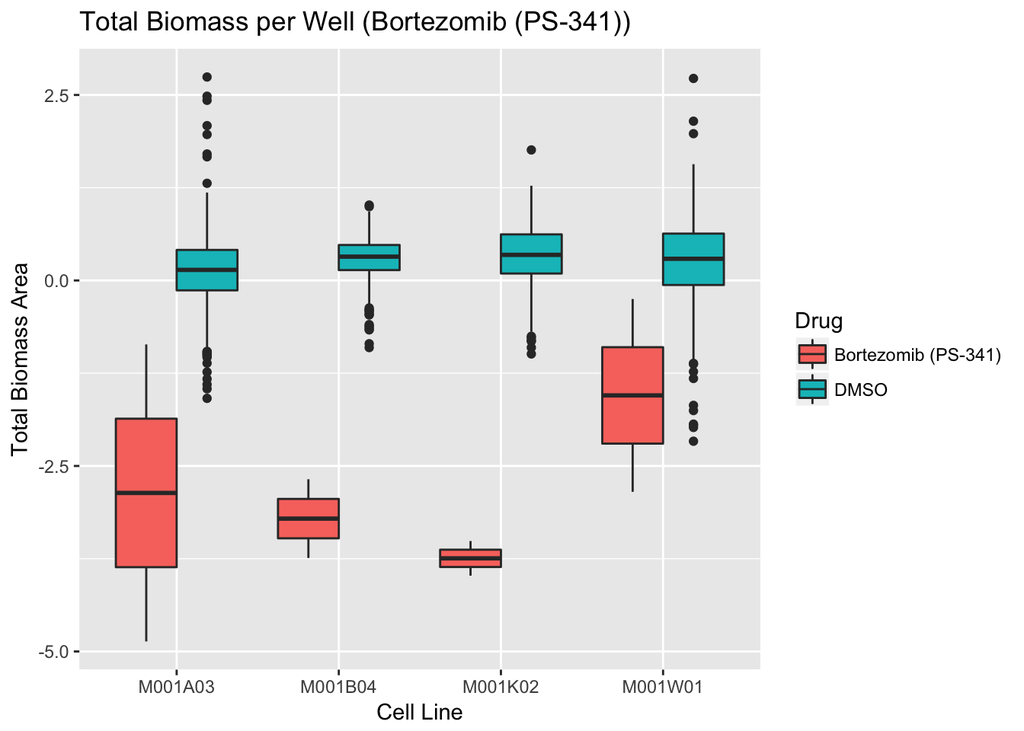

```r
ggplot(data = ggplotdf) + geom_boxplot(aes(x = Cell.Line, y = Total.Area, fill = Drug)) +
  ggtitle(label = "Total Biomass per Well (Bortezomib (PS-341))") +
  xlab("Cell Line") + ylab("Total Biomass Area")
```

## 2.2 Combining Positive Controls

This section is currently redundant but will make sense once more positive pseudo-controls are selected for the mouse screens.

```r
valid_entries = features_metadata$DRUG %in% c("DMSO", "Bortezomib (PS-341)")
features_combined = features[valid_entries,]
features_metadata_combined = features_metadata[valid_entries,]
features_metadata_combined$DRUG = ifelse(
  test = features_metadata_combined$DRUG == "DMSO",
  yes = "NEG_CTRL", no = "POS_CTRL")
```

```r
simple_features = data.frame(
  "Num.Objects" = features_combined[,"organoids_num.of.objects"],
  "Avg.Org.Size" = features_combined[,"organoids_x.0.s.area_expected"],
  "Total.Area" = features_combined[,"Total.Biomass"],
  "Drug" = features_metadata_combined[,"DRUG"],
  "Cell.Line" = substr(rownames(features_combined), 1, 7)
)
```

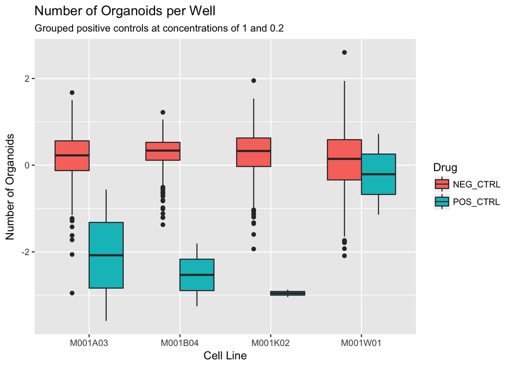

```r
ggplot(data = simple_features) + geom_boxplot(aes(x = Cell.Line, y = Num.Objects, fill = Drug)) +
  ggtitle(label = "Number of Organoids per Well",
          subtitle = "Grouped positive controls at concentrations of 1 and 0.2") + xlab("Cell Line") +
  ylab("Number of Organoids")
```

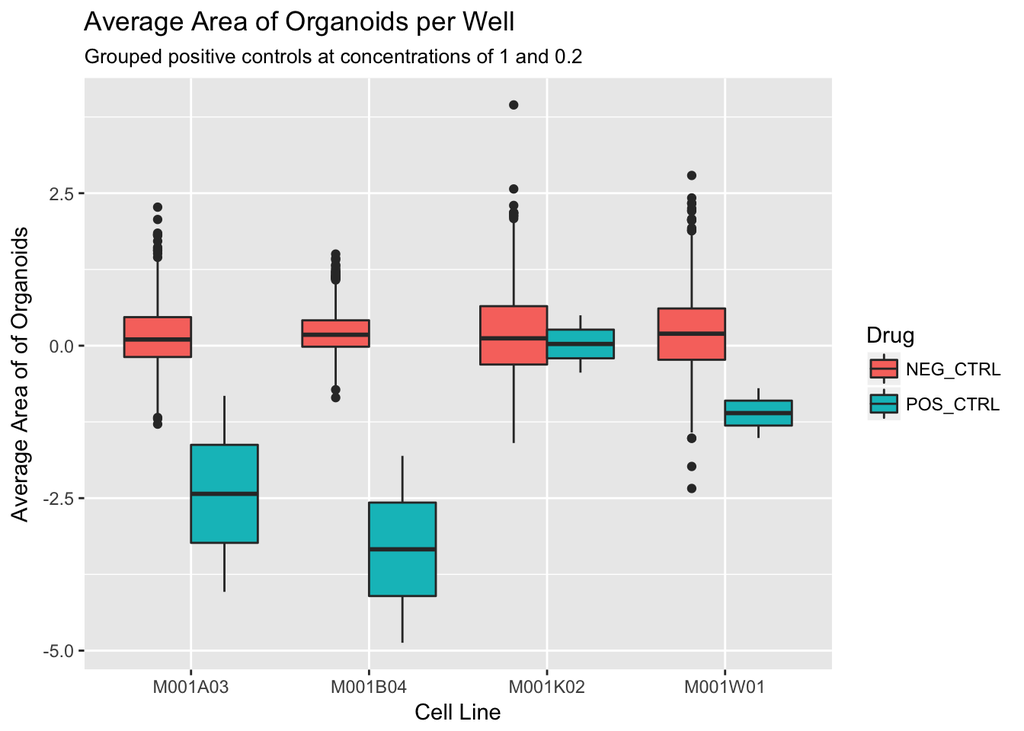

```r
ggplot(data = simple_features) + geom_boxplot(aes(x = Cell.Line, y = Avg.Org.Size, fill = Drug)) +
  ggtitle(label = "Average Area of Organoids per Well",
          subtitle = "Grouped positive controls at concentrations of 1 and 0.2") + xlab("Cell Line") +
  ylab("Average Area of of Organoids")
```

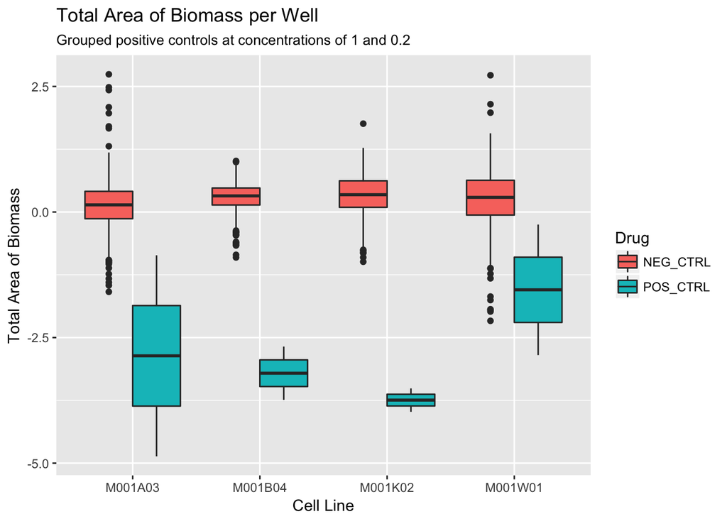

```r
ggplot(data = simple_features) + geom_boxplot(aes(x = Cell.Line, y = Total.Area, fill = Drug)) +
  ggtitle(label = "Total Area of Biomass per Well",
          subtitle = "Grouped positive controls at concentrations of 1 and 0.2") + xlab("Cell Line") +
  ylab("Total Area of Biomass")
```

## 2.3 Cell Line Quality

The average number of organoids as well as the total biomass are features that should vary strongly between the two controls. Consequently, I will exclude any cell lines for which the two controls cannot be properly separated. For this, I determine the z-factor for both the biomass and the number of organoids:

$$Z^\prime = 1 - \frac{3 \cdot (\sigma_p + \sigma_n)}{|\mu_p - \mu_n|}$$

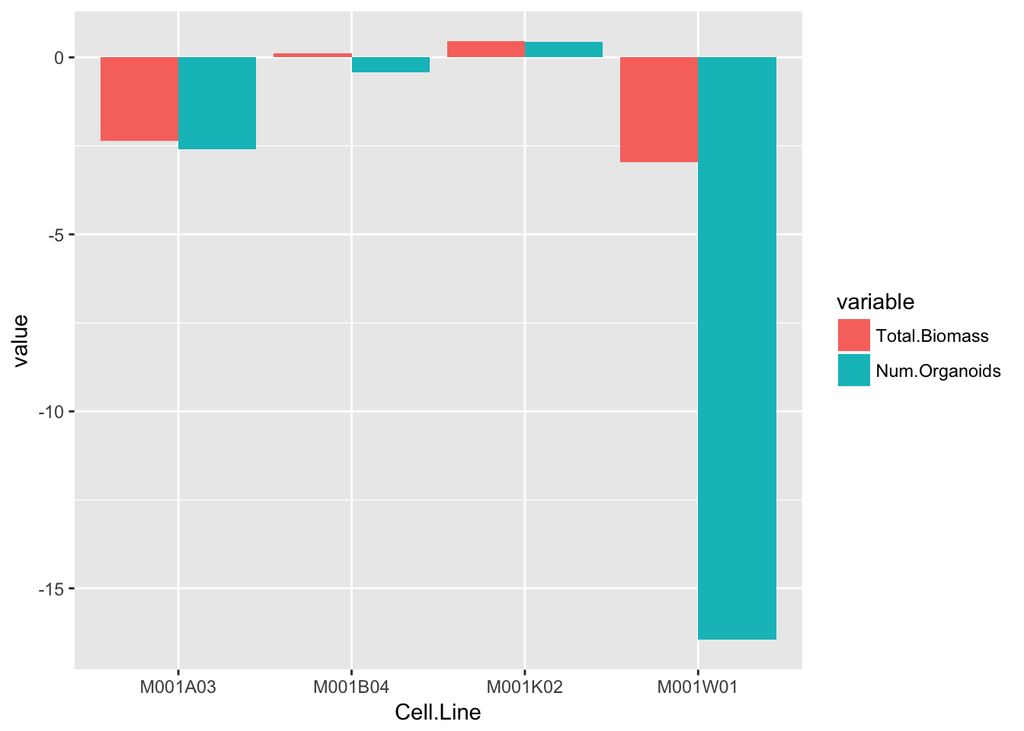

```r
biomass_zprime = setNames(
  object = vector(mode="numeric", length=length(cell_lines)),
  nm = cell_lines)
organoids_zprime = setNames(
  object = vector(mode="numeric", length=length(cell_lines)),
  nm = cell_lines)
for(cell_line in cell_lines) {
  cl_simple_features = simple_features[simple_features$Cell.Line == cell_line, ]
  organoids_zprime[[cell_line]] = zprime(
    cl_simple_features[cl_simple_features$Drug == "NEG_CTRL", "Num.Objects"],
    cl_simple_features[cl_simple_features$Drug == "POS_CTRL", "Num.Objects"],
    method = "robust")
  biomass_zprime[[cell_line]] = zprime(
    cl_simple_features[cl_simple_features$Drug == "NEG_CTRL", "Total.Area"],
    cl_simple_features[cl_simple_features$Drug == "POS_CTRL", "Total.Area"],
    method = "robust")
}
ggplotdf = data.frame(
  "Cell.Line" = names(organoids_zprime),
  "Total.Biomass" = biomass_zprime,
  "Num.Organoids" = organoids_zprime)
ggplotdf = melt(ggplotdf, id.vars = "Cell.Line")
ggplot(data = ggplotdf) +
  geom_col(aes(x = Cell.Line, y = value, fill = variable),
           position = position_dodge())
```

```r
wilcox_organoids_p = setNames(
  object = vector(mode="numeric", length=length(cell_lines)),
  nm = cell_lines)
wilcox_biomass_p = setNames(
  object = vector(mode="numeric", length=length(cell_lines)),
  nm = cell_lines)
for(cell_line in cell_lines) {
  cl_simple_features = simple_features[simple_features$Cell.Line == cell_line, ]
  wilcox_organoids_p[[cell_line]] = wilcox.test(
    cl_simple_features[cl_simple_features$Drug == "NEG_CTRL", "Num.Objects"],
    cl_simple_features[cl_simple_features$Drug == "POS_CTRL", "Num.Objects"],
    conf.int = TRUE)$p.value
  wilcox_biomass_p[[cell_line]] = wilcox.test(
    cl_simple_features[cl_simple_features$Drug == "NEG_CTRL", "Total.Area"],
    cl_simple_features[cl_simple_features$Drug == "POS_CTRL", "Total.Area"],
    conf.int = TRUE)$p.value
}

panderdf = data.frame(
  "Total.Biomass" = wilcox_biomass_p,
  "Num.Objects" = wilcox_organoids_p)
pandoc.table(
  panderdf, emphasize.strong.cells = which(panderdf > 0.05, arr.ind = TRUE),
  caption = "Probabilities that the feature values for the positive and negative controls come from the same distribution (p-values of Wilcoxon test)")
```

```
##
## -------------------------------------------
##    &nbsp;      Total.Biomass   Num.Objects
## ------------- --------------- -------------
##  **M001A03**      0.01715        0.02543
##
##  **M001B04**      0.01457        0.01457
##
##  **M001K02**      0.01457        0.01457
##
##  **M001W01**      0.04304      **0.7449**
## -------------------------------------------
##
## Table: Probabilities that the feature values for the positive and negative controls come from the same distribution (p-values of Wilcoxon test)
```

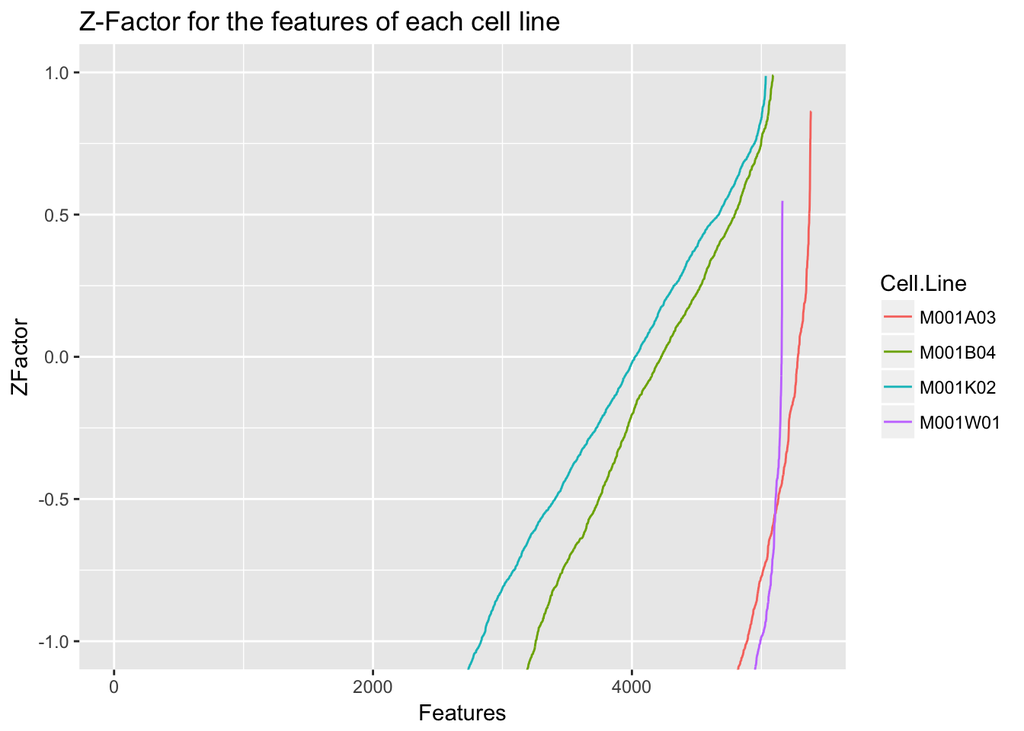

```r
# Calculate z factors for each cell line / feature combination
pos_ctrl = features_combined[features_metadata_combined$DRUG == "POS_CTRL",]
pos_ctrl_metadata = features_metadata_combined[features_metadata_combined$DRUG == "POS_CTRL",]
neg_ctrl = features_combined[features_metadata_combined$DRUG == "NEG_CTRL",]
neg_ctrl_metadata = features_metadata_combined[features_metadata_combined$DRUG == "NEG_CTRL",]
feature_z_factors = matrix(
  NA_real_, nrow = length(cell_lines), ncol = ncol(features_combined),
  dimnames = list(cell_lines, colnames(features_combined)))
for(feature in colnames(features_combined)) {
  for(cell_line in cell_lines) {
    feature_z_factors[cell_line, feature] = zprime(
      pos_ctrl[substr(rownames(pos_ctrl), 1, 7) == cell_line, feature],
      neg_ctrl[substr(rownames(neg_ctrl), 1, 7) == cell_line, feature],
      method = "robust")
  }
}

feature_z_factors_df = apply(feature_z_factors, 1, sort)
feature_z_factors_df = do.call(what = c, args = feature_z_factors_df)
feature_z_factors_df = data.frame(
  "Cell.Line" = sapply(strsplit(names(feature_z_factors_df), ".", fixed = TRUE), "[[", 1),
  "ZFactor" = feature_z_factors_df)
feature_z_factors_df = feature_z_factors_df[is.finite(feature_z_factors_df$ZFactor),]
feature_z_factors_df$Features = NA_real_
for(cell_line in cell_lines) {
  feature_z_factors_df[
    feature_z_factors_df$Cell.Line == cell_line,
    "Features"] = seq_len(table(
      feature_z_factors_df$Cell.Line)[cell_line])
}

ggplot(data = feature_z_factors_df) + geom_line(aes(x = Features, y = ZFactor, color = Cell.Line)) +
  coord_cartesian(ylim = c(-1, 1)) + ggtitle(label = "Z-Factor for the features of each cell line")
```

## 2.4 Pruning Features

Features only make sense if they are sufficiently continuous. I want to discard features that are constant across the negative (DMSO) controls of a plate. A look at the ‘minimum ratio’ of unique values for each feature across plates shows that features are either continuous or constant across a plate, but with a rather large transition inbetween. I keep only features with more than 75% unique values across all plates.

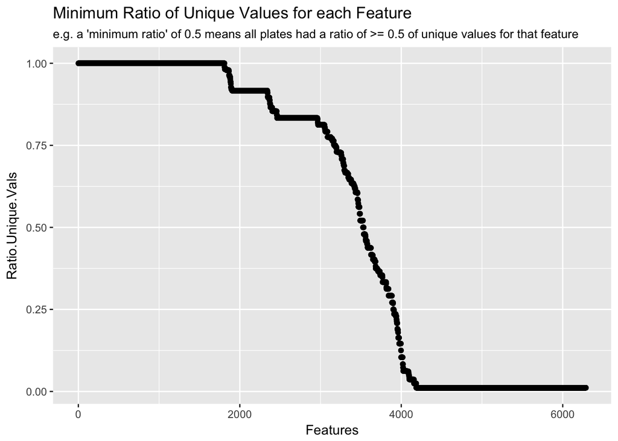

```r
neg_ctrl = features_combined[features_metadata_combined$DRUG == "NEG_CTRL", ]
# This rounding ensures that there are no floating point arithmetic errors that are mistaken as unique values
neg_ctrl = round(neg_ctrl, 8)
neg_ctrl_cl = substr(rownames(neg_ctrl), 1, 14)
unique_vals = aggregate(neg_ctrl, list(neg_ctrl_cl), function(x) length(unique(x)) / length(x))
rownames(unique_vals) = unique_vals$Group.1
unique_vals$Group.1 = NULL
unique_vals_min = apply(unique_vals, 2, min)
unique_vals_min_df = data.frame(
  "Ratio.Unique.Vals" = sort(unique_vals_min, decreasing = TRUE),
  "Features" = seq_along(unique_vals_min))
ggplot(data = unique_vals_min_df) + geom_point(aes(x = Features, y = Ratio.Unique.Vals)) +
  ggtitle("Minimum Ratio of Unique Values for each Feature",
          subtitle = "e.g. a 'minimum ratio' of 0.5 means all plates had a ratio of >= 0.5 of unique values for that feature")
```

```r
features = features[,names(which(unique_vals_min >= 0.75))]
features_combined = features_combined[,names(which(unique_vals_min >= 0.75))]
```

## 2.5 Correlation between replicates

### 2.5.1 Cell line specfific

I look at all features now to see how well they correlate between replicates of the screen for each cell line individually

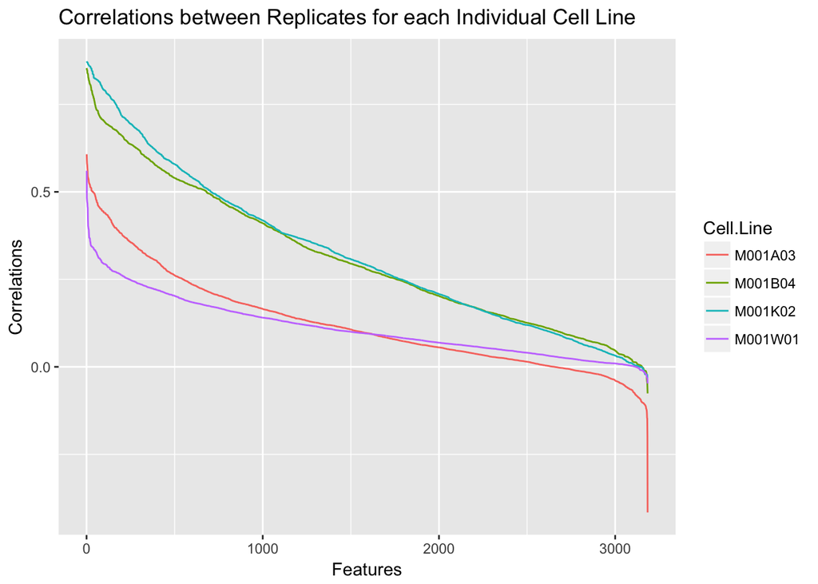

```r
cl_correlations = setNames(
  object = vector(mode = "list", length = length(cell_lines)),
  nm = cell_lines
)
for(cell_line in cell_lines) {
  cl_features = features[substr(rownames(features), 1, 7) == cell_line, ]
  cl_features_metadata = features_metadata[substr(rownames(features_metadata), 1, 7) == cell_line, ]
  rep1 = cl_features[cl_features_metadata$REPLICATE == 1, ]
  rep2 = cl_features[cl_features_metadata$REPLICATE == 2, ]
  if(!identical(paste0(substr(rownames(rep1), 1, 7), "_", substr(rownames(rep1), 12, 19)),
                paste0(substr(rownames(rep2), 1, 7), "_", substr(rownames(rep2), 12, 19)))) {
    warning("Replicates are not in the same order!")
  }
  rep_correlations = setNames(
    object = vector(mode = "numeric", length = ncol(cl_features)),
    nm = colnames(cl_features))
  for(feature in colnames(cl_features)) {
    rep_correlations[[feature]] = cor(
      rep1[[feature]], rep2[[feature]],
      use = "pairwise.complete.obs")
  }
  rep_correlations = sort(rep_correlations, decreasing = TRUE)
  cl_correlations[[cell_line]] = data.frame(
    "Features" = seq_along(rep_correlations),
    "Correlations" = rep_correlations,
    "Cell.Line" = cell_line
  )
}

cl_correlations = do.call(rbind, cl_correlations)
ggplot(data = cl_correlations) + geom_line(aes(x = Features, y = Correlations, color = Cell.Line)) +
  ggtitle("Correlations between Replicates for each Individual Cell Line")
```

### 2.5.2 Screen-wide

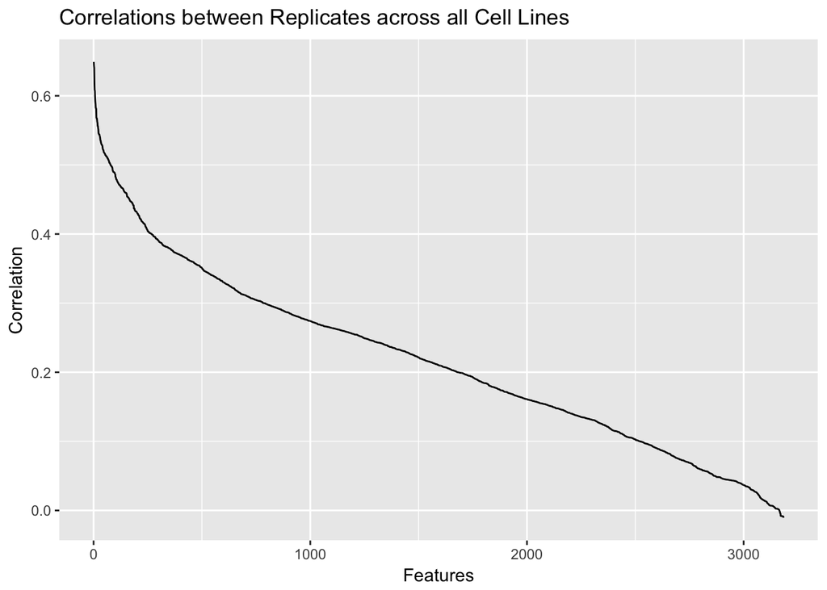

```r
rep1 = features[features_metadata$REPLICATE == 1, ]
rep2 = features[features_metadata$REPLICATE == 2, ]
if(!identical(paste0(substr(rownames(rep1), 1, 7), "_", substr(rownames(rep1), 12, 19)),
              paste0(substr(rownames(rep2), 1, 7), "_", substr(rownames(rep2), 12, 19)))) {
  warning("Replicates are not in the same order!")
}

rep_correlations = setNames(
  object = vector(mode = "numeric", length = ncol(features)),
  nm = colnames(features))
for(feature in colnames(features)) {
  rep_correlations[[feature]] = cor(
    rep1[[feature]], rep2[[feature]],
    use = "pairwise.complete.obs")
}

ggplotdf = data.frame(
  "Features" = seq_along(sort(rep_correlations)),
  "Correlation" = sort(rep_correlations, decreasing = TRUE))
ggplot(data = ggplotdf) + geom_line(aes(x = Features, y = Correlation)) +
  ggtitle("Correlations between Replicates across all Cell Lines")
```